# People-based ML models

Zhenzhao Xu

```r
knitr::opts_chunk$set(
    message = FALSE,
    warning = FALSE,
    results=FALSE,
    fig.align="center",
    cache=T
)
```

```r
library(tidyverse)
library(tidycensus)
library(sf)
library(kableExtra)
library(patchwork)
library(ggplot2)
library(RSocrata)
library(viridis)
library(spatstat)
library(caret)
library(stargazer)
#library(raster)
#library(spdep)
library(FNN)
library(grid)
library(gridExtra)
library(knitr)
library(plotROC)
library(pROC)

options(scipen=999)
options(tigris_class = "sf")
options(tigris_use_cache = TRUE)
source("functions.r")

p5 = inferno(5)
p2 = p5[c(4,2)]
```

## 1. Motivation

The Department of Housing and Community Development (HCD) in Emil City is trying to promote home repair tax credit program, but under the current random campaign method, only about 11% of homeowners they reached out to finally took the credit.

In this context, it is more important to make use of past data, analyze and borrow the experience, and make decision-making analytics. The goal of this project is to find a more effective strategy to select target groups, in order to improve the conversion rate of the campaign, and to make full use of limited campaign resources.

## 2. Feature data visualizations

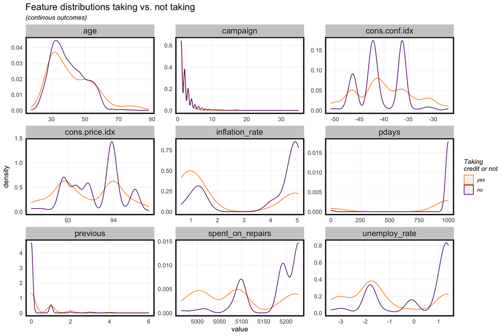

```r
# reading the data
credit = read.csv("./housingSubsidy.csv")%>%
  mutate(y=y%>%fct_rev())%>% # to set the lever order to "yes","no"
  select(-X)

#
credit %>%
    select(y, age, campaign, pdays,previous,unemploy_rate,cons.price.idx,
           cons.conf.idx,inflation_rate,spent_on_repairs) %>%
    gather(Variable, value, -y) %>%
    ggplot() +
    geom_density(aes(value, color=y)) +
    facet_wrap(~Variable, scales = "free") +
    scale_color_manual(values = p2, name="Taking\ncredit or not") +
    labs(title = "Feature distributions taking vs. not taking",
         subtitle = "(continous outcomes)") +
    plotTheme()
```

According to the figure above, age, campaign(number of contacts), previous(number of contacts before) and Pdays(The number of days after last contacted) has little influence on whether the target accepts credit or not.

The changes of the two variables Cons.price.idx(Consumer price Index at campaign time) and cons.conf.idx(Consumer confidence index at time of campaign) have a huge impact on the probability density of the target accepting credit, and the fluctuation of the rejection rate is particularly significant, and it shows a possibility of periodicity. One possible reason is that these two variables change linearly over time, while the probability of accepting credit is periodic over time.

Spent on repairs, unemployment rate, and inflation rate have significant differences in relation to the acceptance of credit near the extreme value, and therefore, they are potentially valuable variables for the model below.

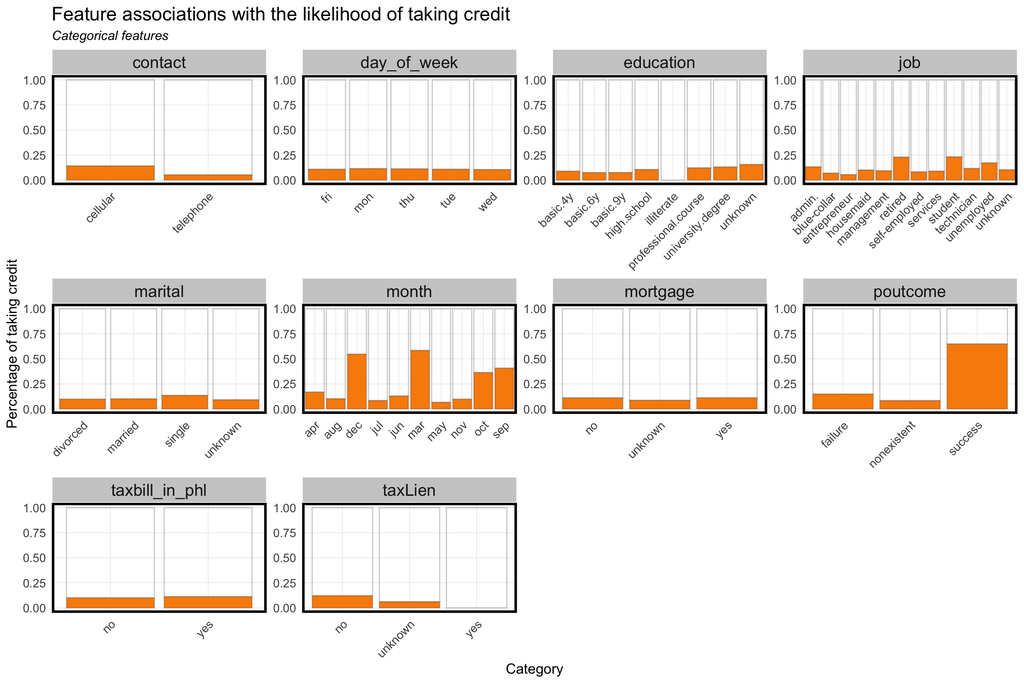

```r
credit %>%
    select(y, job, marital, education,taxLien,mortgage,taxbill_in_phl,
           contact,month,day_of_week,poutcome) %>%
    mutate(y=y%>%fct_rev())%>%
    gather(Variable, value, -y) %>%
    count(Variable, value, y) %>%
      ggplot(., aes(value, n, fill = y)) +
        geom_bar( stat="identity",position = "fill",show.legend = F,
                  color="#00000033") +
        facet_wrap(~Variable, scales="free") +
        scale_fill_manual(values = c("#ffffff00",p2[1]),name="") +
        labs(x="Category", y="Percentage of taking credit",
             title = "Feature associations with the likelihood of taking credit",
             subtitle = "Categorical features") +
        plotTheme()+theme(axis.text.x = element_text(angle = 45, hjust = 1))
```

The figure above optimizes the presentation of data to better exclude the influence of sample size on data perception. In each graph, the X axis is the value of categorical variables, and the Y axis is the percentage of the sample that receives credit.

According to the figure above, variable tax bill in PHL, mortgage, marital, day of week and taxLien have similar proportions in different categories, so they have little influence on the results.

Contact, month, Poutcome (Previous outcome) have a great impact on the results and are more important variables. Targets contacted by cellular had a higher success rate, and the success rate in March, September, October and December was significantly higher than in other months, suggesting a significant annual variation. In addition, recontacting a previously successful target has a success rate of more than 60%, demonstrating the importance of additional contacts with previously successful targets.

## 3. Training/test set splitting

```r
set.seed(1)
credit.trainindex <- createDataPartition(credit$y, p = .65,
                                  list = FALSE,
                                  times = 1)
credit.raw.train <- credit[ credit.trainindex,]
credit.raw.test <- credit[-credit.trainindex,]
```

In this project, a training/test set splitting rate of 0.65/0.35 is applied.

## 4. Feature engineering

### 4.1 New features

```r
credit.engineer =
  credit %>%
  mutate(
    is.unemployed=ifelse(job=="unemployed",1,0),
    is.single = ifelse(marital=="single",1,0),
    is.big.month = ifelse(month%>%str_detect("(mar|dec)"),1,0),
    is.education.basic = ifelse(education%>%str_detect("basic"),1,0)
  )%>%
  select(-education,-day_of_week,-job,-marital,-inflation_rate,-month,-taxLien)
```

Variable “job” is simplified to “is.unemployed”; variable “marital” is simplified to “is.single”; variable “education” is simplified to basic4/6/9 year education or not; variable “month” is simplified to is Mar/Dec or not as the indicator for big month.

These new features are created to replace the old ones, in order to simplify the model. They are the results after repeated tests. Although the overall prediction accuracy of the model doesn’t see a huge improvement, concise models are usually easier to interpret, so these new features are retained.

### 4.2 Regression summary for both regressions

```r
credit.raw.model <- glm(y_numeric ~ .,
                        data=credit.raw.train%>%select(-y),
                        family="binomial" (link="logit"))

credit.e.train = credit.engineer[ credit.trainindex,]
credit.e.test = credit.engineer[-credit.trainindex,]

credit.e.model = glm(y_numeric ~ .,
                        data=credit.e.train%>%select(-y),
                        family="binomial" (link="logit"))
# summary(credit.raw.model)
# summary(credit.e.model)
stargazer(credit.raw.model,credit.e.model, type = 'html')
```

|  | *Dependent variable:* |  |
| --- | --- | --- |
|  | y_numeric |  |
|  | (1) | (2) |
| age | 0.019** | 0.018*** |
|  | (0.009) | (0.007) |
| jobblue-collar | -0.186 |  |
|  | (0.290) |  |
| jobentrepreneur | -0.374 |  |
|  | (0.475) |  |
| jobhousemaid | -0.011 |  |
|  | (0.480) |  |
| jobmanagement | -0.751** |  |
|  | (0.348) |  |
| jobretired | -0.119 |  |
|  | (0.369) |  |
| jobself-employed | -0.763 |  |
|  | (0.475) |  |
| jobservices | -0.341 |  |
|  | (0.314) |  |
| jobstudent | 0.097 |  |
|  | (0.431) |  |
| jobtechnician | 0.112 |  |
|  | (0.237) |  |
| jobunemployed | 0.567 |  |
|  | (0.423) |  |
| jobunknown | 0.210 |  |
|  | (0.776) |  |
| maritalmarried | 0.206 |  |
|  | (0.258) |  |
| maritalsingle | 0.422 |  |
|  | (0.294) |  |

[output cut: 88 more lines]

The engineered model is much neater than the raw one.

```r
testProbs = data.frame(Outcome = as.factor(credit.e.test$y_numeric),
                        Probs = predict(credit.e.model, credit.e.test, type= "response"))%>%
  mutate(predOutcome = as.factor(ifelse(Probs > 0.125 , 1, 0)))
caret::confusionMatrix(testProbs$predOutcome, testProbs$Outcome, positive = "1")
```

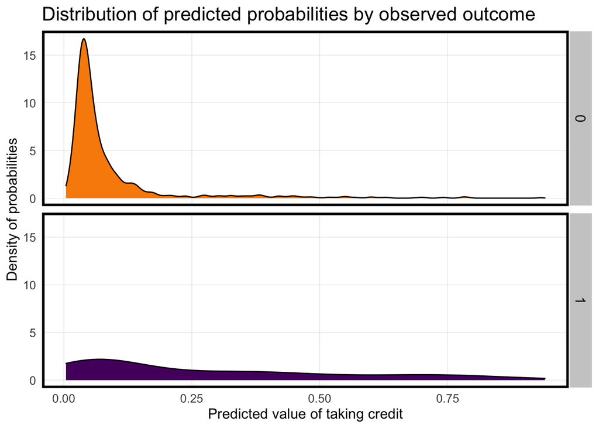

```r
ggplot(testProbs, aes(x = Probs, fill = as.factor(Outcome))) +
  geom_density() +
  facet_grid(Outcome ~ .) +
  scale_fill_manual(values = p2) +
  labs(x = "Predicted value of taking credit", y = "Density of probabilities",
       title = "Distribution of predicted probabilities by observed outcome") +plotTheme()+
  theme(strip.text.x = element_text(size = 18),
        legend.position = "none")
```

From the figure above, the distinction between the two values of dependent variables is not significant, which is one of the reasons for the low sensitivity. They share an extreme value of around 0.07, with the tail of taking credit being more pronounced.

### 4.3 Cross Validation

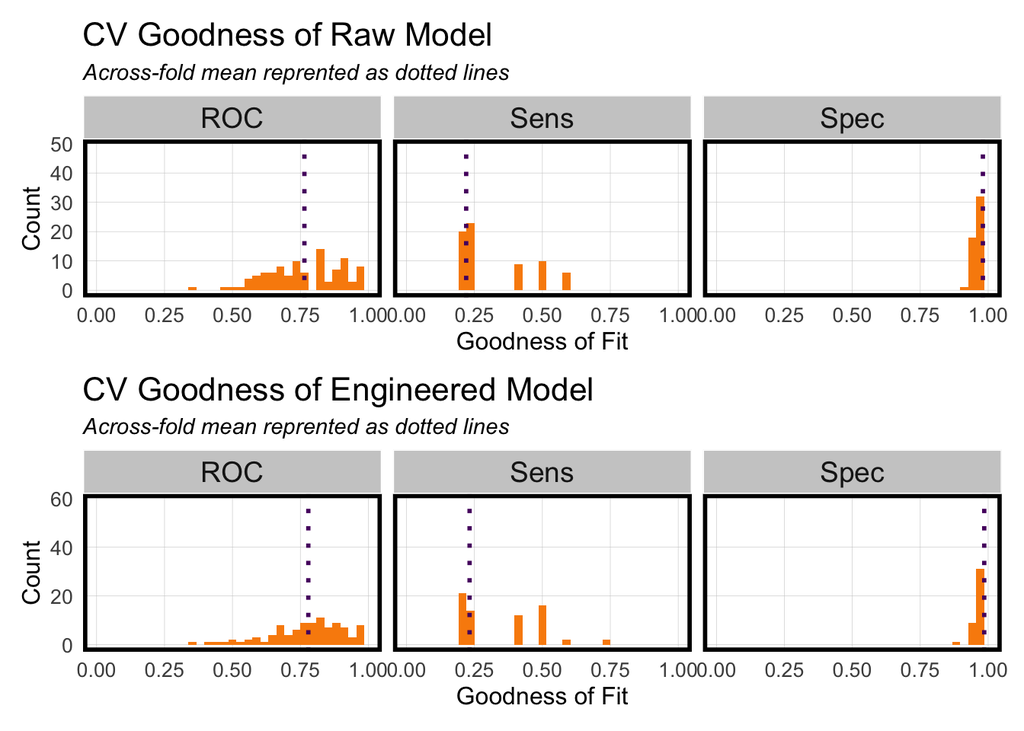

```r
ctrl = trainControl(method = "cv", number = 100, classProbs=TRUE, summaryFunction=twoClassSummary)
cvFit.raw = train(y ~ ., data = credit%>%select(-y_numeric),
                method="glm", family="binomial",
                metric="ROC", trControl = ctrl)

cvFit.e = train(y ~ ., data = credit.engineer%>%select(-y_numeric),
                method="glm", family="binomial",
                metric="ROC", trControl = ctrl)
cvFit.e

plot1 = select(cvFit.raw$resample, -Resample) %>%
  gather(metric, value) %>%
  left_join(gather(cvFit.raw$results[2:4], metric, mean)) %>%
  ggplot(aes(value)) +
    geom_histogram(bins=35, fill = p2[1]) +
    facet_wrap(~metric) +
    geom_vline(aes(xintercept = mean), colour = p2[2], linetype = 3, size = 1) +
    scale_x_continuous(limits = c(0, 1)) +
    labs(x="Goodness of Fit", y="Count", title="CV Goodness of Raw Model",
         subtitle = "Across-fold mean reprented as dotted lines") +
    plotTheme()

plot2 = select(cvFit.e$resample, -Resample) %>%
  gather(metric, value) %>%
  left_join(gather(cvFit.e$results[2:4], metric, mean)) %>%
  ggplot(aes(value)) +
    geom_histogram(bins=35, fill = p2[1]) +
    facet_wrap(~metric) +
    geom_vline(aes(xintercept = mean), colour = p2[2], linetype = 3, size = 1) +
    scale_x_continuous(limits = c(0, 1)) +
    labs(x="Goodness of Fit", y="Count", title="CV Goodness of Engineered Model",
         subtitle = "Across-fold mean reprented as dotted lines") +
    plotTheme()

plot1/plot2
```

The results of cross validation of these two models are similar, indicating that the improvement of accuracy by Engineer is limited. From the perspective of ROC, the engineered model’s ROC distribution is more concentrated, indicating that it is more generalizable, but it does not generalize with respect to sensitivity. However, specificity of these models both have a very high value.

## 5. ROC curve

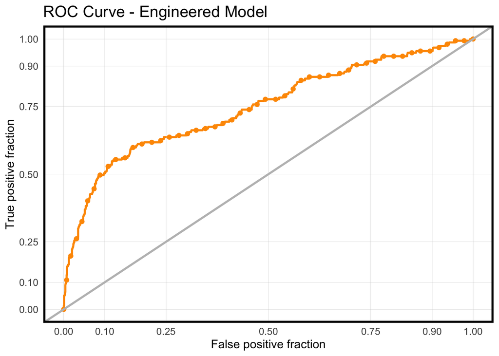

```r
ggplot(testProbs, aes(d = as.numeric(testProbs$Outcome), m = Probs)) +
  geom_roc(n.cuts = 50, labels = FALSE, colour = "#FE9900") +
  style_roc(theme = theme_grey) +
  geom_abline(slope = 1, intercept = 0, size = 1, color = 'grey') +
  labs(title = "ROC Curve - Engineered Model")+
  plotTheme()
```

A receiver operating characteristic curve, or ROC curve, is a graphical plot that illustrates the diagnostic ability of a binary classifier system as its discrimination threshold is varied. The plot above indicates that the engineered model has a pretty good performance. The points on the curve shows the “trade-offs” of a certain threshold. For instance, the point (0.25, 0.62) shows that this threshold finds FP 25% of the time, and finds TP finds FP 62% of the time.

```r
pROC::auc(testProbs$Outcome, testProbs$Probs)
```

Area under the curve: 0.7475

The “Area Under the Curve” metric or AUC for this model is 0.7475, also shows that this model is a fair one.

## 6. Cost benefit analysis

### 6.1 Cost/benefit equation

A cost-benefit equation is used to optimize the threshold for the best outcome. As is estimated, marketing resources cost is $2,850 per homeowner, the credit costs $5,000 per homeowner, and houses that transacted after taking the credit has a average premium of $10,000, and surrounding the repaired home see an aggregate premium of $56,000, so the sum of $66,000 is considered as campaign benefit.

It is said that about 25% of contacted eligible homeowners take the credit, but in this project, this rate is considered as the rate of TP/(TP+FP), and it is assumed that all TP would take the credit, in order to make TP fit its definition.

**True Positive** - Predicted correctly homeowner would take the credit; allocated the marketing resources, and they took the credit.

**True Negative** - Predicted correctly homeowner would not take the credit, no marketing resources were allocated, and no credit was allocated.

**False Positive** - Predicted incorrectly homeowner would take the credit; allocated marketing resources; no credit allocated.

**False Negative** - We predicted that a homeowner would not take the credit but they did. These are likely homeowners who signed up for reasons unrelated to the marketing campaign. Thus, we ‘0 out’ this category, assuming the cost/benefit of this is $0.

[output not shown]

- $66,000 is the benefit of homeowners. The benefit from the perspective of the public sector should be discounted. Here, the discount rate is assumed to be 0.5.

### 6.2 Cost/Benefit Table

```r
cost_benefit_table <-
   testProbs %>%
      count(predOutcome, Outcome) %>%
      summarize(True_Negative = sum(n[predOutcome==0 & Outcome==0]),
                True_Positive = sum(n[predOutcome==1 & Outcome==1]),
                False_Negative = sum(n[predOutcome==0 & Outcome==1]),
                False_Positive = sum(n[predOutcome==1 & Outcome==0])) %>%
       gather(Variable, Count) %>%
       mutate(Revenue =
               case_when(Variable == "True_Negative"  ~ Count * 0,
                         Variable == "True_Positive"  ~ Count * 25250,
                         Variable == "False_Negative" ~ 0,
                         Variable == "False_Positive" ~ -2850 * Count)) %>%
    bind_cols(data.frame(Description = c(
              "Predicted correctly homeowner would not take the credit",
              "Predicted correctly homeowner would take the credit",
              "We predicted that a homeowner would not take the credit but they did",
              "Predicted incorrectly homeowner would take the credit")))
cost_benefit_table%>%
  kable()%>%kable_styling()
```

| Variable | Count | Revenue | Description |
| --- | --- | --- | --- |
| True_Negative | 1097 | 0 | Predicted correctly homeowner would not take the credit |
| True_Positive | 88 | 2222000 | Predicted correctly homeowner would take the credit |
| False_Negative | 69 | 0 | We predicted that a homeowner would not take the credit but they did |
| False_Positive | 186 | -530100 | Predicted incorrectly homeowner would take the credit |

### 6.3 Confusion metric outcomes

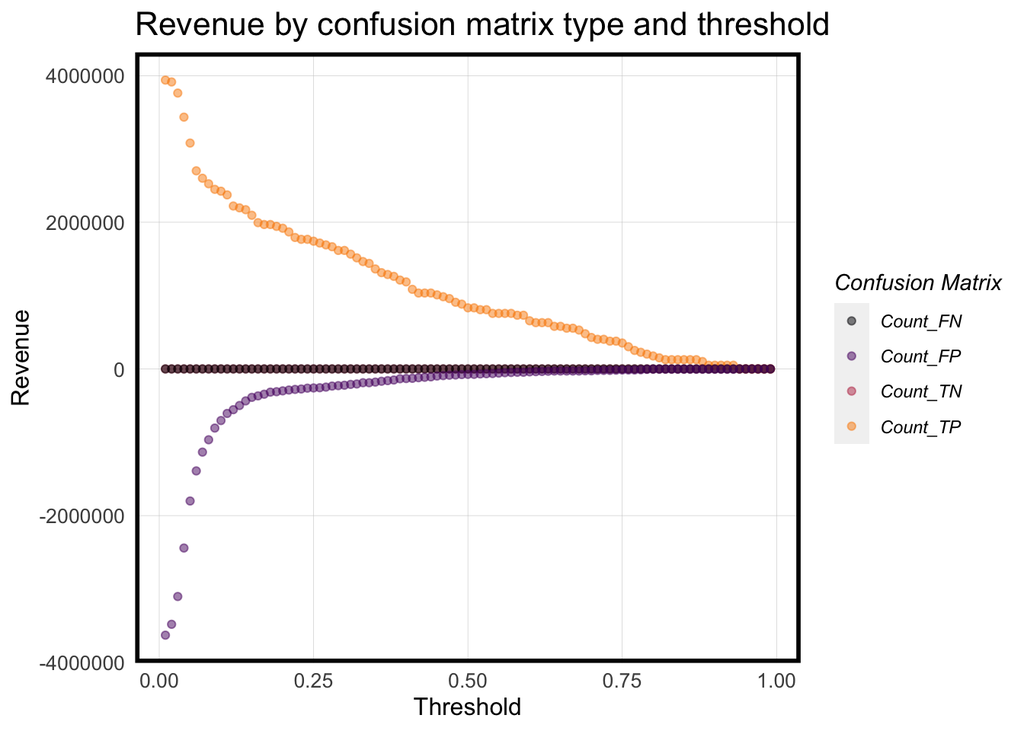

```r
whichThreshold =
  iterateThresholds(
     data=testProbs, observedClass = Outcome, predictedProbs = Probs)

whichThreshold =
  whichThreshold %>%
    dplyr::select(starts_with("Count"), Threshold) %>%
    gather(Variable, Count, -Threshold) %>%
    mutate(Revenue =
             case_when(Variable == "Count_TN"  ~ 0,
                       Variable == "Count_TP"  ~ Count * 25250,
                       Variable == "Count_FN"  ~ 0,
                       Variable == "Count_FP"  ~ -2850 * Count))
whichThreshold %>%
  ggplot(.,aes(Threshold, Revenue, colour = Variable)) +
  geom_point(alpha=.5) +
  scale_colour_manual(values = p5[c(1:5)]) +
  labs(title = "Revenue by confusion matrix type and threshold",
       y = "Revenue") +
  plotTheme() +
  guides(colour=guide_legend(title = "Confusion Matrix"))
```

### 6.4 Threshold as a function of Total_Revenue and Total_Count_of_Credits

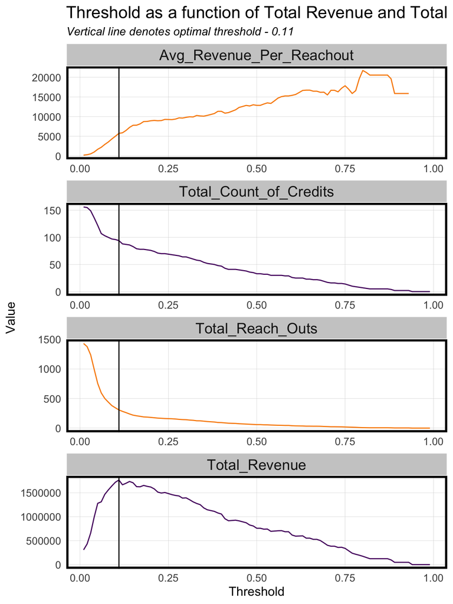

```r
whichThreshold_revenue <-
  whichThreshold %>%
    mutate(Total_Count_of_Credits = ifelse(Variable == "Count_TP",Count,0),
           Total_Reach_Outs = ifelse(Variable%>%str_detect("(Count_FP|Count_TP)"),Count,0)) %>%
    group_by(Threshold) %>%
    summarize(Total_Revenue = sum(Revenue),
              Total_Count_of_Credits=sum(Total_Count_of_Credits),
              Total_Reach_Outs = sum(Total_Reach_Outs),
              Positive_Predictive_Value = Total_Count_of_Credits/Total_Reach_Outs,
              Avg_Revenue_Per_Reachout = Total_Revenue/Total_Reach_Outs)

whichThreshold_revenue %>%
  dplyr::select(Threshold, Total_Revenue, Total_Count_of_Credits,
                Total_Reach_Outs,Avg_Revenue_Per_Reachout) %>%
  gather(Variable, Value, -Threshold) %>%
  ggplot(aes(Threshold, Value, colour = Variable)) +
    geom_line(show.legend = F) +
    geom_vline(xintercept = pull(arrange(whichThreshold_revenue, -Total_Revenue)[1,1])) +
    scale_colour_manual(values = rep(p2,3)) +
    plotTheme() + #ylim(0,70000) +
    facet_wrap(~Variable,scales = "free",ncol = 1)+
    labs(title = "Threshold as a function of Total Revenue and Total Count of Credits",
         subtitle = "Vertical line denotes optimal threshold - 0.11")
```

### 6.5 Table of the Total_Revenue

```r
k = whichThreshold_revenue%>%
  filter(Threshold%in%c(0.50,0.11))%>%
  select(Threshold,Total_Revenue,Total_Count_of_Credits)%>%
  kable()%>% kable_styling()

k
```

| Threshold | Total_Revenue | Total_Count_of_Credits |
| --- | --- | --- |
| 0.11 | 1766450 | 94 |
| 0.50 | 759150 | 33 |

## 7. Conclusion

The limits of the model is: the algorithm `GLM` is used, further improvement of this project could use other models instead to advance accuracy. In addition, if there are more variables about the current condition of houses, the income of the owner or accurate time, the sensitivity of the model may also increase.

For marketing materials, HCD should implement the following strategies to increase the response rate: pay more attention to older people, communicate more with targets through mobile devices, and keep an eye on targets that have expressed interest in the past.